# **El CITOverso**

Guía para el análisis bidimensional de datos de citometría de flujo mediante programas de R

Jairo R. Villanueva-Toledo

2024-12-30

# **BIENVENIDA**

¡Bienvenidos a este fascinante viaje por el mundo de la citometría de flujo (CF) y la bioinformática! En las páginas que siguen, exploraremos estas dos disciplinas científicas que, al unirse, nos permiten desentrañar los misterios de la biología celular y molecular con una precisión sin precedentes.

La citometría de flujo nos brinda la capacidad de analizar y clasificar células individuales en tiempo real, revelando detalles cruciales sobre su tamaño, complejidad y características específicas. Por otro lado, la bioinformática nos proporciona las herramientas necesarias para interpretar y gestionar la enorme cantidad de datos generados por estas técnicas avanzadas, permitiéndonos descubrir patrones y relaciones que de otro modo pasarían desapercibidos.

Este libro está concebido como una referencia integral para profesionales con experiencia intermedia que buscan profundizar en sus conocimientos y habilidades en estas áreas. A lo largo de los capítulos, los lectores encontrarán explicaciones claras, ejemplos prácticos y consejos útiles que les permitirán llevar a cabo un análisis más avanzado y reproducible de los datos obtenidos de la CF mediante el uso de herramientas bioinformáticas.

Espero que disfruten de esta aventura científica y que, al finalizar la lectura, se sientan inspirados y capacitados para aplicar estos conocimientos en sus propias investigaciones y proyectos. ¡Adelante, el mundo de la citometría de flujo y la bioinformática les espera!

# **PREFACIO**

## A quién va dirigido este libro

EL **CITOverso** está dirigido a toda persona del área biomédica interesada en aprender a realizar análisis de datos de citometría de flujo utilizando programas informáticos de uso libre mediante códigos. Esto incluye tanto a estudiantes de pregrado como a estudiantes de posgrado que planean incorporar esta técnica en sus proyectos para responder a sus preguntas de investigación.

## Motivación

Durante mi formación académica, escuché de varios de mis maestros que una forma efectiva de aprender es enseñar. Por lo tanto, el motivo que me llevó a escribir el presente libro es, principalmente, compartir los conocimientos adquiridos en ambas áreas del conocimiento a lo largo de los años.

## Estructura del libro

En “El **Citoverso**”, se revisarán los diferentes conceptos y pasos propuestos por expertos en el área para llevar a cabo un análisis bidimensional de datos de CF. Este libro está diseñado para guiar al lector desde una comprensión intermedia hasta una más compleja y exhaustiva. Cada capítulo comenzará con una introducción a los principios fundamentales de la CF, explicando cómo se recopilan y procesan los datos. A medida que avancemos, exploraremos técnicas específicas para el análisis bidimensional, incluyendo la visualización y la interpretación de los resultados. Al final del libro, el lector contará con una sólida comprensión de cómo realizar análisis bidimensionales efectivos y estará preparado para abordar problemas más avanzados en el campo de la CF.

## Acotaciones

Ese libro está orientado a servir como una guía para el análisis de datos de CF mediante programas bioinformáticos utilizando R. Ni más, ni menos

La CF y la bioinformática son temas vastos y multifacéticos, por lo que es natural que no **todo** pueda ser cubierto en esta guía.

A pesar de que se requiere conocimiento previo en CF, se proporciona una introducción a cada tema para facilitar su comprensión.

Para aquellas personas que desean profundizar en ambas áreas del conocimiento, se proporciona referencias a recursos adecuados para seguir aprendiendo.

Es importante tener en cuenta que algunos temas avanzados presentados en este libro pueden resultar más desafiantes para quienes no cuenten con conocimientos previos de CF.

Se recomienda seguir el contenido de manera secuencial para aprovechar al máximo el aprendizaje.

## Consideraciones

- Se asumirá que ya cuentan con R y RStudio instalados.
- Se presume que poseen conocimientos de nivel intermedio-avanzado en citometría de flujo.
- Se considera que tienen conocimientos de nivel básico-intermedio en programación en el lenguaje R.

# **ACERCA DEL AUTOR**

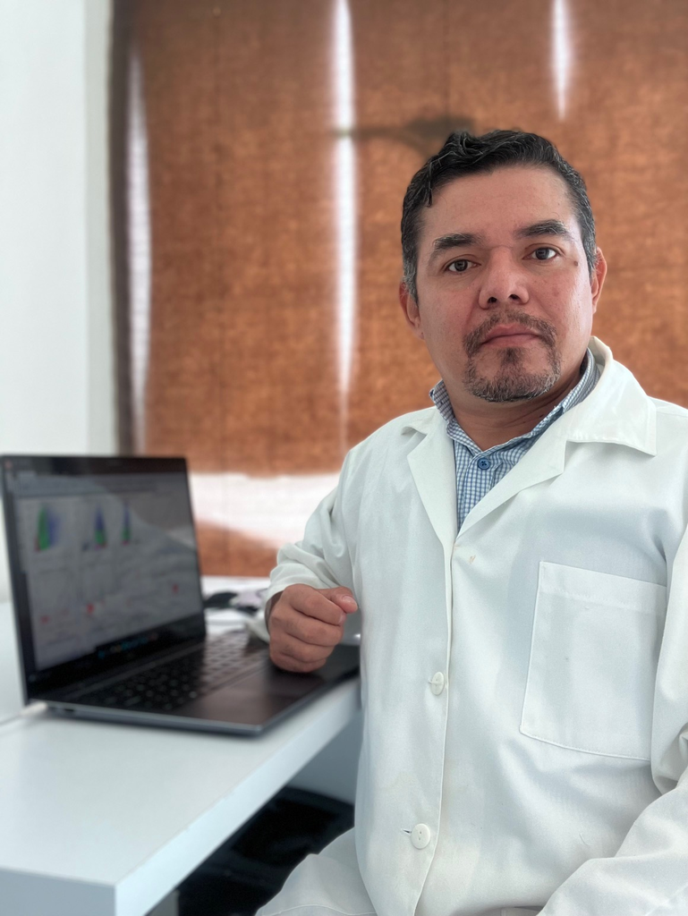

Mi nombre es **Jairo Ricardo Villanueva Toledo**. Soy Médico Cirujano de formación por la Universidad Autónoma de Yucatán ([**UADY**](https://uady.mx/)), con estudios de posgrado (maestría y doctorado en ciencias en la especialidad de genética y biología molecular) en el Centro de Investigación y de Estudios Avanzados del Instituto Politécnico Nacional ([**CINVESTAV-IPN**](https://www.cinvestav.mx/)), sede Zacatenco, en la Ciudad de México, México.

Mi primer acercamiento tanto a la CF como a la bioinformática se produjo durante mis estudios de maestría. Mi incursión en ambas áreas del conocimiento se dio de manera paralela: en bioinformática, para el análisis de secuencias génicas (principalmente análisis de BLAST y diseño de “primers”), y en citometría de flujo, para el análisis del ciclo celular. Al término de mis estudios de posgrado, inicié mi carrera profesional en el área comercial, donde me desempeñé como asesor científico comercial en una empresa líder especializada en el desarrollo y la comercialización de citómetros de flujo, lo que me permitió interactuar más de cerca y conocer a fondo las entrañas de dichos equipos.

Actualmente, soy académico del programa de Investigadores por México de la Secretaría de Ciencia, Humanidades, Tecnología e Innovación ([**SECIHTI**](https://secihti.mx/)**)**, comisionado al Hospital de Alta Especialidad de la Península de Yucatán ([**HRAEPY**](https://www.gob.mx/salud/hraepy/)) del IMSS Bienestar, y profesor del capítulo de citometría de flujo de la Sociedad Mexicana de Inmunología, donde participo activamente impartiendo talleres sobre algunas de las técnicas más utilizadas en citometría de flujo.

# **El CITOverso**

## **CAPÍTULO 1**. Introducción a el CITOverso

La citometría de flujo es una técnica poderosa utilizada en biología y medicina para analizar las características físicas y químicas de partículas en suspensión. Este método se ha convertido en una herramienta esencial en la investigación biomédica debido a su capacidad para realizar análisis rápidos y precisos de miles de células en segundos. Sin embargo, el inmenso volumen y la complejidad de esta información requieren herramientas informáticas avanzadas para su interpretación efectiva. En este sentido, la bioinformática juega un papel crucial, ofreciendo algoritmos y plataformas que permiten visualizar, analizar y extraer información valiosa de los datos obtenidos por CF.

En este contexto, surge el concepto de “CITOverso”, un universo en el que se integran conceptos de CF y se analizan los datos correspondientes mediante enfoques bioinformáticos.

**Objetivos del capítulo 1:**

- Enunciar los alcances del CITOverso.
- Revisar las características generales de los actores principales del CITOverso: equipos y programas informáticos.

El CITOverso es un ecosistema en el que la CF y la bioinformática convergen para transformar el análisis celular. La CF es una técnica poderosa que permite estudiar miles de células por segundo, proporcionando datos detallados sobre sus características físicas y moleculares. Sin embargo, el inmenso volumen y la complejidad de esta información requieren herramientas informáticas avanzadas para su interpretación efectiva. Aquí es donde la bioinformática juega un papel crucial, ofreciendo algoritmos y plataformas que permiten visualizar, analizar y extraer información valiosa de los datos obtenidos por CF.

### Equipos

Los citómetros de flujo han evolucionado de manera significativa a lo largo del tiempo, los cambios que han experimentado abarcan desde la forma en que captan y procesan la señal lumínica hasta aspectos informáticos. Como resultado, en la actualidad contamos con diversos citómetros de flujo que presentan distintas capacidades y características.

Desde el punto de vista regulatorio, los citómetros de flujo pueden catalogarse según su finalidad en aquellos de uso clínico y de investigación. En relación con su capacidad para separar células, se pueden clasificar en “cell sorters” y analizadores. Los “cell sorters” están diseñados para recuperar las células, si así se desea, mientras que los analizadores carecen de esta capacidad, lo que implica que las células sean desechadas.

> **Nota**: Las regulaciones sanitarias varían según las leyes de cada país; por lo tanto, todo lo mencionado en el libro Citometría Bioinformática está relacionado exclusivamente con fines de investigación.

Tradicionalmente, en la CF se emplean fluorocromos (orgánicos e inorgánicos) acoplados a anticuerpos monoclonales para identificar los antígenos de interés. Los fluorocromos, al ser excitados por la luz del láser apropiado, emiten señal lumínica (fotones), la cual es captada por los detectores para su posterior procesamiento. Dependiendo de la cantidad de fotones proveniente de los fluorocromos que son capaces de captar, los citómetros se pueden dividir en: espectro parcial (los citómetros tradicionales) y espectro completo (conocidos como espectrales). Un inconveniente que poseen los fluorocromos es que el espectro de la señal lumínica que emiten suele ser muy amplia, llegando a ser captada por más de un detector. Por ello, una estrategia propuesta para subsanar este fenómeno es el uso de elementos raros de la tabla periódica en sustitución de fluorocromos, cuyo espectro de señal emitida es más compacto. Tomando en cuenta esto, es que se desarrolló el citómetro de masas.

> **Tip**: Una de las preguntas que más frecuentemente me hacían en mi labor como asesor científico comercial es: ¿Cuál es el mejor citómetro de flujo? Desde mi perspectiva, el mejor citómetro es aquel que permite responder de manera efectiva tu pregunta de investigación.

### Programas Informáticos

Al igual que los equipos, los programas informáticos pueden clasificarse según su estatus regulatorio en aquellos destinados al uso clínico y aquellos orientados a la investigación. Independientemente de su estatus regulatorio, estos programas se dividen en dos categorías: adquisición y análisis. Los programas de adquisición, que vienen instalados con el equipo, funcionan como la interfaz principal entre el operador y el instrumento, por lo que es fundamental que sean eficientes y especializados.

Lo primero y más importante que cualquiera desea hacer, tras llevar a cabo un experimento de CF y recopilar los datos es analizarlos. Para realizar el análisis de manera adecuada en el campo de la CF, es fundamental contar con un programa de análisis de datos. Existen diversas opciones de programas de análisis disponibles, los cuales se pueden clasificar en dos tipos: comerciales y de uso gratuito. Los programas comerciales requieren el pago de una licencia para su uso; generalmente, estos programas son fáciles de utilizar y de código cerrado. Por otro lado, los programas de uso gratuito pueden variar en su facilidad de uso; algunos son intuitivos, mientras que otros requieren conocimientos de programación en lenguajes como [R](https://www.r-project.org/) y/o [Python](https://www.python.org/). Estos últimos suelen ser de código abierto, lo que implica que, si posees habilidades de programación, puedes modificarlos. En este libro, nos centraremos en el uso del lenguaje de programación R para el análisis de datos de CF.

> **Nota**: Al ser R un programa informático gratuito y de código abierto, es posible alcanzar el mismo resultado mediante diversas formas y estrategias.

## **CAPÍTULO 2**. Preparación del espacio de trabajo.

Implementar una estructura coherente de carpetas en todos los proyectos favorece la organización y simplifica el guardado y la localización de información en el futuro. La organización de “scripts”, datos y resultados en carpetas contribuye a establecer un entorno de trabajo bien estructurado, facilitando así el análisis en R. Esta práctica resulta especialmente beneficiosa al gestionar múltiples proyectos. En términos generales, se sugiere crear directorios (carpetas) específicos para “scripts”, datos, documentos y resultadoss.

### **Objetivos del capítulo 2**:

- Definir que es un “script”

### Entorno de trabajo en RStudio

[figure not shown]

**Figura 1**. Ventanas de trabajo en RStudio.

1. Ventana del editor (también llamada ventana de “script”).
2. Ventana de espacio de trabajo / historial.
3. Ventana de consola (también llamada ventana de comandos).
4. Ventana de archivos / gráficos / paquetes / ayuda.

### “Scripts”

Un “script” en R es un documento de texto que contiene un conjunto de comandos y código que pueden ejecutarse en el entorno de R. Los “scripts” se utilizan para automatizar tareas, realizar análisis repetitivos, y para mantener un registro claro y organizado del trabajo en R.

### Directorio de trabajo

Lo primero que se debe especificar es el directorio de trabajo en el que se alojará el proyecto. Un directorio de trabajo es el lugar (carpeta) en la computadora en la que se está trabajando actualmente. Cuando se le solicita a R que abra un archivo determinado, buscará ese archivo en el directorio de trabajo, y cuando se le indica que guarde un archivo de datos o una figura, lo almacenará en el directorio de trabajo. Para conocer el directorio de trabajo en la que se encuentra actualmente trabajanod, la función `getwd()` es útil:

```r
# Ejemplo
getwd()
```

Si se desea cambiar el directorio de trabajo, la función `setwd("direccion/del/directorio")` es útil:

```r
# Ejemplo
setwd("C:/Users/nombre/Documents")
```

> **NOTAS**: Las diagonales invertidas deberán ser del tipo `/`, ya que de lo contrario pueden surgir errores en los pasos subsiguientes.

Se recomienda crear una carpeta, como usualmente se hace, denominada “CitBio” en la carpeta “Mis Documentos” ( aunque puede ser creada en la ubicación que se prefiera y nombrada como se desee; sin embargo, por cuestiones de practicidad y estar acorde con las indicaciones subsecuentes, se sugiere seguir estas recomendaciones). Una vez creada la carpeta “CitBio”, será necesario identificar la dirección completa de la carpeta en la que se encuentra alojada en la computadora, la cual se utilizará con la función `setwd("ruta/del/directorio")`:

Una vez definido y especificado el directorio de trabajo, se procederá a la creación de carpetas mediante la función `dir.create("nombre_carpeta")`. A continuación, se presentan algunos ejemplos de directorios sugeridos:

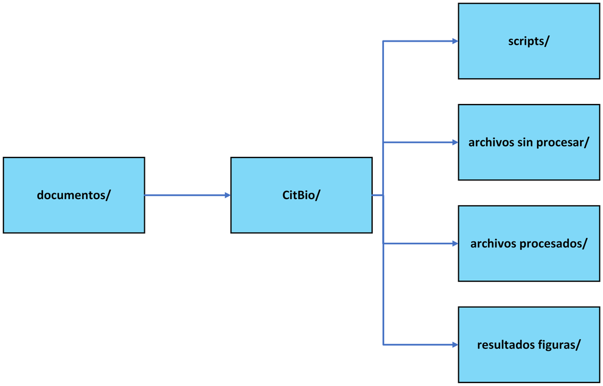

**Figura 2**. Ejemplo de un directorio de trabajo.

```r
dir.create("scripts")
dir.create("archivos sin procesar")
dir.create("archivos procesados")
dir.create("resultados figuras")
```

> **NOTA**: Es factible añadir directorios o subdirectorios adicionales según las necesidades del proyecto.

## **CAPÍTULO 3**. Flujo de trabajo.

En la CF, al igual que en otras áreas que manejan datos complejos y multidimensionales, un flujo de trabajo efectivo facilita la identificación de patrones celulares y la toma de decisiones informadas. La integración de herramientas informáticas en este flujo de trabajo contribuye a maximizar la eficiencia y optimizar el uso del tiempo y los recursos. Por lo tanto, contar con un proceso de procesamiento de datos estandarizado es esencial para obtener resultados reproducibles y conclusiones más cercanas a la realidad.

### **Objetivos del capítulo 3**:

El flujo de trabajo en el análisis de datos de CF representa la hoja de ruta que orienta cada etapa, desde la recolección de muestras hasta la interpretación de resultados. Este proceso estructurado garantiza la aplicación de procedimientos consistente y reproducibles, lo que a su vez mejora la calidad y confiabilidad de los hallazgos.

El análisis de datos de CF generalmente se engloba en tres etapas principales: 1) preprocesamiento de datos y control de calidad; 2) identificación de poblaciones; y 3) análisis estadístico e interpretación de los resultados. La primera etapa consiste tanto en identificar y eliminar los eventos atípicos o no deseados, así como en aumentar la relación señal/ruido de los datos crudos (sin procesar), con el objetivo de proporcionar a las etapas subsiguientes datos de la mayor calidad posible. La segunda etapa tiene como objetivo etiquetar los eventos con los nombres de las poblaciones celulares de interés. La tercera etapa, que es un poco más compleja, puede abarcar desde la descripción poblacional más simple, mediante conteos y frecuencias, hasta la construcción de modelos complejos de predicción para un resultado específico.

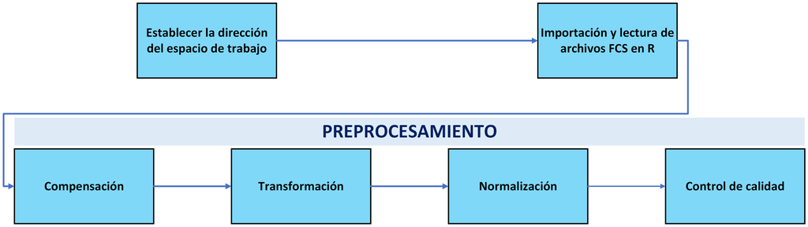

**Figura 3**. Pasos para el análisis de archivos de citometría de flujo.

> **Nota**: Los flujos de trabajo para las diversas plataformas, ya sean citómetros de espectro parcial, completo o de masas, son en gran medida similares, aunque presentan algunas características particulares inherentes a cada una de ellas. El CITOverso se centrará en cómo realizar el análisis con datos obtenidos de citómetros de flujo de espectro parcial (los tradicionales).

## **CAPÍTULO 4**. Instalación y activación de paquetes de R.

Una manera de incrementar la funcionalidad de R sin necesidad de escribir todo el código desde cero es a través de los denominados paquetes, que representan soluciones ya creadas para problemas comunes en el análisis de datos. Su uso fomenta la colaboración y el intercambio de conocimientos dentro de la comunidad de R. Contar con una amplia variedad de paquetes no solo optimiza el tiempo y los recursos al evitar escribir código desde cero, sino que también mejora la reproducibilidad y la calidad de los análisis al emplear herramientas ya probadas y validadas por otros.

### **Objetivos del capítulo 4**:

- Conocer los conceptos fundamentales sobre los paquetes en [R](https://www.r-project.org/): qué son y por qué es recomendable en nuestro trabajo con [R](https://www.r-project.org/) y donde se pueden localizar.

Un paquete consiste en un conjunto de funciones, datos y documentación organizados con el propósito de simplificar su uso y distribución. Cada paquete puede incluir tres apartados: funciones, datos y documentación. En el apartado de funciones se encuentra el código diseñado para realizar tareas específicas, mientras que en el apartado datos se localizan los datos disponibles para ejemplos o pruebas. Por último, en el apartado de documentación se incluyen las guías sobre como utilizar las funciones y los datos que contiene el paquete.

### **¿Cómo instalar un paquete R?**

Los paquetes de R se encuentran normalmente alojados en repositorios, los cuales facilitan el acceso a una amplia variedad de paquetes desarrollados por la comunidad de usuarios de [R](https://www.r-project.org/). Existen diferentes tipos de repositorios que alojan paquetes no solo de [R](https://www.r-project.org/); los principales son: [**CRAN**](https://cran.r-project.org/), [**Bioconductor**](https://bioconductor.org/) y [**GitHub**](https://github.com/).

> **NOTA**: Cada repositorio tiene su forma particular para la instalación de paquetes.

#### **Desde CRAN**

[CRAN](https://cran.r-project.org/), que significa Comprehensive R Archive Network, es un repositorio en línea para el lenguaje de programación [R](https://www.r-project.org/). Se trata de una fuente centralizada donde se pueden [encontrar, descargar e instalar](https://cran.r-project.org/web/packages/available_packages_by_name.html) paquetes de [R](https://www.r-project.org/).

El repositorio [CRAN](https://cran.r-project.org/) alberga una vasta colección de paquetes de [R](https://www.r-project.org/), diseñados para satisfacer una amplia gama de necesidades y funciones. Para descargar paquetes alojados en [CRAN](https://cran.r-project.org/), utilizamos la función `install.packages("nombre_del_paquete")`, la cual forma parte del paquete base {**utils**}, que se instala automáticamente al instalar [R](https://www.r-project.org/).

> **NOTA**: El nombre del paquete debe escribirse tal como es, ya que el lenguaje [R](https://www.r-project.org/) discrimina entre mayúsculas y minúsculas. Además, al utilizar la función `install.packages()`, el nombre de los paquetes debe ir entre comillas.

```r
# Ejemplo
install.packages("ggplot2")
```

Es posible instalar 2 o más paquetes con la función `install.packages()`, separando los nombres de los paquetes con una coma.

```r
# Ejemplo
install.packages("nombre_del_paquete1", "nombre_del_paquete2", "etc")
```

> **NOTA**: El lenguaje R distingue entre errores (**Error**), advertencias (**Warning**) y mensajes simples (**diagnostic messages**). Solo el primero indica que tu código no pudo ejecutarse. Las advertencias sugieren que tu código se ejecutó, pero que algo podría haber salido mal. Los mensajes significan que tu código se ejecutó completamente y, por lo general, se muestran cuando una función desea llamar tu atención sobre algo que ha realizado en segundo plano.

#### **Desde BioConductor**

[Bioconductor](https://bioconductor.org/) es un repositorio especializado en paquetes destinados a la bioinformática y al análisis de datos. La instalación de paquetes que se encuentran alojados en el repositorio [Bioconductor](https://www.bioconductor.org/) requiere, en primer lugar, instalar el paquete {**BiocManager**}. Para llevar a cabo la instalación del paquete, debemos utilizar las siguientes líneas de comando:

```r
if (!require("BiocManager", quietly = TRUE))
  install.packages("BiocManager")
BiocManager::install(version = "3.20")
```

> **NOTA**: Si estás interesado en obtener más información sobre el paquete {**BiocManager**}, te recomiendo revisar su [vignette](https://cran.r-project.org/web/packages/BiocManager/vignettes/BiocManager.html).

Después de haber instalado el paquete {**BiocManager**}, ahora sí seremos capaces de descargar los paquetes que se encuentran alojados en el repositorio Bioconductor mediante el siguiente código: `BiocManager::install("nombre_del_paquete")`

```r
# Ejemplo
BiocManager::install("flowCore")
```

Es posible instalar dos o más paquetes utilizando la función `BiocManager::install()`. A continuación, se presenta un ejemplo de cómo realizar esta operación:

```r
# Ejemplo
BiocManager::install(c("nombre_del_paquete1", "nombre_del_paquete2", "etc"))
```

#### **Desde GitHub**

[GitHub](https://github.com/) es una plataforma basada en la web que permite a los desarrolladores colaborar en proyectos de programas informáticos. Funciona como un sistema de control de versiones y un repositorio de código, facilitando el trabajo en equipo y la gestión de proyectos de programación. Muchos desarrolladores publican sus paquetes en [GitHub](https://github.com/) antes de que sean oficialmente lanzados en [CRAN](https://cran.r-project.org/) o [Bioconductor](https://www.bioconductor.org/), lo que resulta útil para acceder a las versiones más recientes o en desarrollo de dichos paquetes.

La instalación de paquetes desde GitHub puede resultar algo laboriosa, ya que es necesario conocer la cuenta del autor o autores que desarrollaron el paquete. A menudo, es preciso instalar primero el paquete {**devtools**}. Por ejemplo, si se desea instalar un paquete que fue publicado en un artículo reciente o se busca obtener la versión más reciente y/o en desarrollo de un paquete conocido, es fundamental localizar la página del desarrollador en GitHub o en el repositorio donde haya alojado el paquete. Supongamos que se desea instalar el paquete {**flowCore**}; en este caso, sería necesario acceder a la página de [RGLab](https://github.com/RGLab/flowCore), donde se encuentra alojado, y localizar el paquete correspondiente.

```r
# Ejemplo
devtools::install_github("RGLab/flowCore")
```

> **NOTA**: No es necesario instalar el o los paquetes cada vez que inicies una sesión de R; sin embargo, si es necesario activar los paquetes que requieras según el análisis que desees realizar.

### **¿Cómo “activar” un paquete R?**

Una vez que el o los paquetes estén instalados, es necesario activarlos para poder utilizarlos en la sesión de trabajo. Para activar un paquete, puedes hacerlo a través de la función `library(),` sin necesidad de escribir el nombre del paquete entre comillas. Esto permite que todas las funciones y datos del paquete estén disponibles para su uso en tu sesión.

```r
# Ejemplo
library(flowCore)
library(ggplot2)
```

> **NOTA**: Si el paquete ya está instalado pero no lo activas con `library()`, R no reconocerá las funciones y datos que contiene. Por lo tanto, es necesario activar el o los paquetes cada vez que desees utilizarlos en una nueva sesión.

#### Actualización de los paquetes

Si deseas actualizar todos los paquetes que has descargado, puedes hacerlo usando el siguiente código:

```r
# Actualización de paquetes
update.packages()
```

#### Addendum

La razón por la cual todos podemos acceder a estos paquetes de forma gratuita es que expertos de todo el mundo han dedicado una considerable cantidad de tiempo y esfuerzo a su desarrollo, generalmente sin recibir compensación económica. Si decides utilizar alguno de los paquetes mencionados en este libro, te invito cordialmente a que los cites de manera adecuada.

Puedes obtener la información necesaria de cada paquete para citarlos adecuadamente utilizando el siguiente código: `citation("nombre_del_paquete")`.

```r
# Ejemplo
citation("flowCore")
```

## **CAPÍTULO 5**. Archivos FCS.

Los datos generados por la mayoría de los citómetros de flujo actuales se almacenan en un formato estandarizado conocido por sus siglas como FCS (Flow Cytometry Standard). La importación de archivos FCS a R facilita el procesamiento y análisis de estos datos, aprovechando la robustez y flexibilidad del lenguaje R. Mediante el uso de paquetes especializados como {**flowCore**}, es posible leer, transformar y visualizar datos de citometría de flujo de manera eficiente. La integración de estos datos con otras herramientas bioinformáticas potencia el análisis, haciéndolo más robusto.

### **Objetivos del capítulo 5**:

El formato FCS proporciona la información necesaria para describir detalladamente: a) el instrumento utilizado para obtener los datos; b) la muestra analizada; c) los datos obtenidos; y d) el análisis preliminar de los datos. El propósito fundamental de contar con un formato estándar es disponer de un documento uniforme que facilite el análisis de los archivos generados por los diferentes tipos de citómetros de flujo, asegurando así su compatibilidad con cualquier programa de análisis disponible.

A lo largo del tiempo, este formato (**Figura 4**) ha experimentado cambios estructurales y de estilo en sus diferentes segmentos, como consecuencia del avance tanto en los equipos como en las estrategias de análisis. En el transcurso del texto, nos referiremos a la versión FCS 3.0, que es la más utilizada en la mayoría de los citómetros. Haremos referencia a las diferencias existentes con la versión FCS 3.1 cuando sea pertinente.

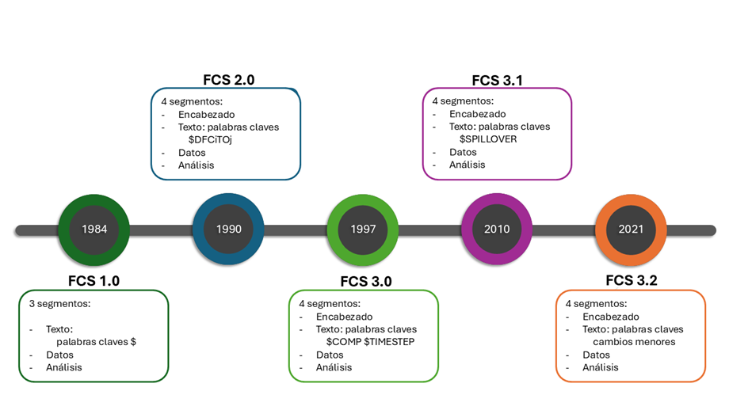

**Figura 4**. Evolución del formato estandarizado FCS a lo largo del tiempo.

> **NOTA**: Los archivos generados por ciertos tipos de citómetros de flujo tienen la extensión LMD, los cuales está integrados por 2 archivos FCS: una versión 2.0 y otra 3.0.

El archivo FCS se compone de varios segmentos (**Figura 5**), que varían según la versión, por nombrar algunos de ellos (los más relevantes para el curso) son: 1. Encabezado (Header), 2. Text (texto), 3 Datos (data) y 4. Análisis (analysis) (Spidlen et al. 2015).

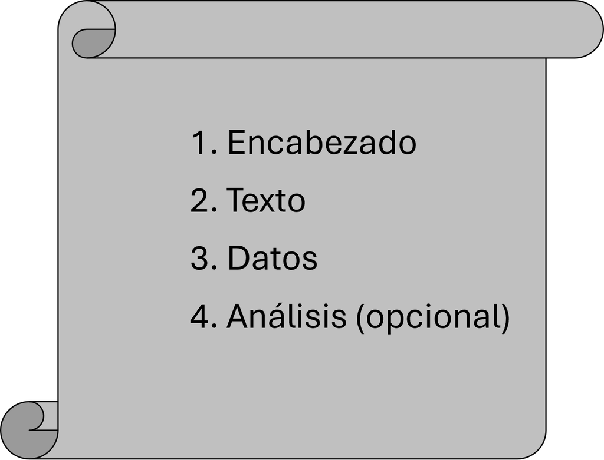

**Figura 5**. Representación gráfica de un archivo FCS y sus segmentos correspondientes.

> **NOTA**: Independientemente del citómetro utilizado, ya sea de espectro parcial o completo, o incluso un citómetro de masas, el formato de los archivos generados por cada uno de ellos presenta una estructura similar, con cambios mínimos y puntuales.

## Archivos de trabajo

Por cuestiones de practicidad, utilizaremos los archivos que vienen con el paquete flowCore, agrupados bajo el nombre de GvHD. Los archivos GvHD contienen datos de un experimento de monitoreo de la enfermedad injerto contra huésped (GvHD, por sus siglas en inglés). Este conjunto de datos es una colección de muestras de sangre periférica obtenidas de pacientes, las cuales fueron recolectadas semanalmente después de un trasplante alogénico de sangre y médula ósea. El conjunto de datos GvHD incluye mediciones de un biomarcador para leucocitos en cinco pacientes a lo largo de siete visitas (siete puntos en el tiempo). Las muestras de sangre fueron etiquetadas con cuatro sondas fluorescentes diferentes para identificar el biomarcador, y la intensidad fluorescente se determinó para al menos diez mil células por muestra. Cada archivo en el conjunto de datos representa una muestra en un punto de tiempo específico y está organizado en un objeto de clase flowSet, compuesto por 35 FlowFrames. Estos datos son útiles para identificar biomarcadores que predicen el desarrollo de GvHD y permiten realizar análisis detallados de citometría de flujo (CF).

> **NOTA**: Se recomienda que, simultáneamente, el lector aplique lo propuesto a sus propios archivos.

## **CAPÍTULO 6**. Importación y lectura de archivos FCS en R.

### **¿Cómo importar un archivo FCS en R?**

Para utilizar tus datos en R, es necesario importarlos y convertirlos en un objeto de R. Para importar un archivo FCS a R, es fundamental conocer la dirección en el disco duro de nuestra computadora donde se encuentran alojados el o los archivos FCS.

```r
# Ejemplo
miarchivo <- system.file("extdata", "0877408774.B08",
                         package = "flowCore")
```

> **NOTA**: Como se mencionó anteriormente, los paquetes incluyen datos de demostración con los que fueron probados. En el ejemplo, la función `system.file()` se utiliza para acceder a los archivos de datos incluidos en un paquete. “exdata” es la carpeta en la que se encuentra el archivo, y “0877408774.B08” es el nombre del archivo.

> Por cuestiones de practicidad, utilizaremos los archivos que vienen con el paquete flowCore, agrupados bajo el nombre de GvHD, como ejemplo para que el lector aplique lo aquí indicado a sus propios datos. Los archivos GvHD contienen datos de un experimento de monitoreo de la enfermedad injerto contra huésped (GvHD, por sus siglas en inglés).

En el siguiente ejemplo, los archivos con extensión FCS que se utilizarán se encuentran alojados en una carpeta llamada “Archivos”, ubicada en los documentos de la unidad C de la computadora. Por lo que, la dirección que se debe especificar sería algo similiar a “`C:\Users\name\Documents\Archivos`”

```r
# Ejemplo
mi_archivo <- "C:\Users\name\Documents\Archivos"
```

{**flowCore**} es un paquete fundamental para el análisis de datos de citometría de flujo en R, cuya tarea principal es la representación y manipulación básica de archivos FCS (o similares). Ofrece una estructura de datos computacionalmente eficiente para la lectura y almacenamiento de datos de CF y proporciona un análisis sistemático de archivos FCS. Además, incluye una variedad de métodos para el procesamiento de datos, que abarcan la compensación, transformación y establecimiento de “*gates*”.

La unidad básica de manipulación en {**flowCore**} es el “**flowFrame**”, que corresponde a un único archivo FCS exportado desde el programa de adquisición del citómetro de flujo. Actualmente, este paquete permite la lectura de archivos FCS de las versiones 2.0, 3.0 y 3.1, así como de archivos con extensiones LMD (List Mode Data, por sus siglas en inglés).

{**flowViz**} ofrece herramientas de visualización, mientras que {**flowQC**} proporciona herramientas de control de calidad y evaluación de calidad de datos de CF.

Cuando se generan cientos datos y se guardan en archivos FCS, el procesamiento puede convertirse en un desafío, ya que se puede alcanzar el límite de la memoria RAM al leer todos los datos. {**ncdfFlow**} es un paquete de BioConductor diseñado para superar las limitaciones de memoria al trabajar con grandes conjuntos de datos, permitiendo el acceso a los datos FCS directamente desde el disco duro y evitando la necesidad de cargar todos los datos del archivo en la memoria RAM.

## **CAPÍTULO 7**. Compensación.

## **CAPÍTULO 8**. Transformación.

## **CAPÍTULO 9**. Normalización.

## **CAPÍTULO 10**. Control de calidad.

## **CAPÍTULO 11**. Visualización de los datos.

## **CAPÍTULO 12.** Análisis y reporte.

# **Referencias bibliográficas**

Spidlen, Josef, Chris Bray, ISAC Data Standards Task Force, and Ryan R. Brinkman. 2015. “ISAC’s Classification Results File Format.” *Cytometry Part A* 87 (1): 86–88. https://doi.org/10.1002/cyto.a.22586.